# Armando Torner y Victor Marinas

### **Diciembre, 2019**

## Indice

- 1. Introduccion
- 2. Importción de Datos
- 3. Target
- 4. Reducción de Variables
- 5. Pre-procesamiento y Análisis Exploratorio
- 6. Pre-procesamiento de Datos
- 7. Modelo Lasso
- 8. Modelo Training and Testing
- 9. Regresión Logistica
- 10. Support Vector Machine
- 11. Random Forest
- 12. XGBoost
- 13. Conclusiones

# 1.- Introducción

[LendingClub](https://www.lendingclub.com/) es una empresa estadounidense de préstamos entre pares y la plataforma de préstamos entre pares más grande del mundo. Según lo explicado por [Wikipedia](https://en.wikipedia.org/wiki/Lending_Club),

> Lending Club permite a los prestatarios crear préstamos personales no garantizados entre $ 1,000 y \ $ 40,000$. El plazo estándar del préstamo es de tres años. Los inversores pueden buscar y explorar los listados de préstamos en el sitio web de Lending Club y seleccionar los préstamos en los que desean invertir en función de la información suministrada sobre el prestatario, el monto del préstamo, el grado del préstamo y el propósito del préstamo. Los inversores ganan dinero con intereses. Lending Club gana dinero cobrando a los prestatarios una tarifa de apertura e inversores una tarifa de servicio.

El objetivo de este proyecto es construir un modelo de aprendizaje automático para predecir la probabilidad de que un préstamo se cancele. Intentaremos utilizar solo los datos disponibles para los inversores a través de la lista de préstamos de LendingClub, incluida la información sobre el prestatario (ingresos, duración del empleo, puntaje FICO, relación deuda-ingresos, etc.) y la lista de préstamos (monto del préstamo, préstamo propósito, grado de préstamo, tasa de interés, cuota, etc.). Tal modelo predictivo podría ayudar a los inversores de LendingClub a tomar decisiones de inversión mejor informadas. Solo consideraremos los préstamos que LendingClub aceptó según su política de suscripción de crédito.

## 1.1 Referencias :

- Información de LendingClub
  - [LendingClub website](https://www.lendingclub.com/)
  - [LendingClub Wikipedia page](https://en.wikipedia.org/wiki/Lending_Club)

# 2.- Importacion de Datos

```python
#Cargamos las librerias necesarias y preparamos el documento:
```

```python
import numpy as np
import scipy as sp
import pandas as pd
import matplotlib as mpl
import matplotlib.pyplot as plt
import seaborn as sns

# Pandas options
pd.set_option('display.max_colwidth', 1000, 'display.max_rows', None, 'display.max_columns', None)

# Plotting options
%matplotlib inline
mpl.style.use('ggplot')
sns.set(style='whitegrid')
```

**Cargamos el dataset en un dataframe:**

```python
directorio_datos = 'test_set.csv'

loans = pd.read_csv(directorio_datos, index_col = 0)
```

*Chequeamos la información del dataframe:*

```python
loans.info()
```

```
<class 'pandas.core.frame.DataFrame'>
Int64Index: 332020 entries, 1000000 to 1332019
Columns: 145 entries, id to target
dtypes: float64(105), int64(5), object(35)
memory usage: 369.8+ MB
```

Echamos un vistazo a 5 filas seleccionadas al azar. Cada fila corresponde a un solo préstamo.

```python
loans.head(5)
```

|  | id | member_id | loan_amnt | funded_amnt | funded_amnt_inv | term | int_rate | installment | grade | sub_grade | emp_title | emp_length | home_ownership | annual_inc | verification_status | issue_d | pymnt_plan | url | desc | purpose | title | zip_code | addr_state | dti | delinq_2yrs | earliest_cr_line | inq_last_6mths | mths_since_last_delinq | mths_since_last_record | … |
| --- | --- | --- | --- | --- | --- | --- | --- | --- | --- | --- | --- | --- | --- | --- | --- | --- | --- | --- | --- | --- | --- | --- | --- | --- | --- | --- | --- | --- | --- | --- |
| 1000000 | NaN | NaN | 20000 | 20000 | 20000.0 | 36 months | 9.49 | 640.57 | B | B2 | Senior Project Manager | 3 years | RENT | 120000.0 | Source Verified | Jul-2016 | n | NaN | NaN | credit_card | Credit card refinancing | 079xx | NJ | 10.89 | 0.0 | May-2009 | 0.0 | NaN | NaN | … |
| 1000001 | NaN | NaN | 2500 | 2500 | 2500.0 | 36 months | 11.47 | 82.41 | B | B5 | medical assistant | 6 years | RENT | 35000.0 | Source Verified | Mar-2016 | n | NaN | NaN | credit_card | Credit card refinancing | 752xx | TX | 17.35 | 0.0 | Feb-2005 | 0.0 | 53.0 | NaN | … |
| 1000002 | NaN | NaN | 17825 | 17825 | 17825.0 | 36 months | 17.99 | 644.33 | D | D2 | Assistant Sales Manager | 3 years | RENT | 119000.0 | Source Verified | Oct-2016 | n | NaN | NaN | debt_consolidation | Debt consolidation | 473xx | IN | 16.87 | 0.0 | Oct-2006 | 1.0 | 24.0 | NaN | … |
| 1000003 | NaN | NaN | 9500 | 9500 | 9500.0 | 36 months | 8.18 | 298.49 | B | B1 | Programmer | 7 years | MORTGAGE | 82000.0 | Source Verified | May-2015 | n | NaN | NaN | credit_card | Credit card refinancing | 850xx | AZ | 24.69 | 0.0 | May-2003 | 1.0 | 37.0 | NaN | … |
| 1000004 | NaN | NaN | 15000 | 15000 | 14800.0 | 36 months | 12.49 | 501.74 | B | B4 | Owner | 10+ years | RENT | 66287.0 | Source Verified | Apr-2014 | n | NaN | NaN | debt_consolidation | Debt consolidation | 773xx | TX | 13.65 | 0.0 | Jun-1988 | 1.0 | NaN | 91.0 | … |

```python
loans.index = range(loans.shape[0])
```

### Adecuación del dataset del profesor Diego Bodas a nuestro código:

```python
loans.rename(columns = {'target':"loan_status"}, inplace=True)
```

```python
loans.loan_status = loans.loan_status.replace({0: "Fully Paid", 1: "Charged Off"})
```

```python
loans.head(1)
```

|  | id | member_id | loan_amnt | funded_amnt | funded_amnt_inv | term | int_rate | installment | grade | sub_grade | emp_title | emp_length | home_ownership | annual_inc | verification_status | issue_d | pymnt_plan | url | desc | purpose | title | zip_code | addr_state | dti | delinq_2yrs | earliest_cr_line | inq_last_6mths | mths_since_last_delinq | mths_since_last_record | … |
| --- | --- | --- | --- | --- | --- | --- | --- | --- | --- | --- | --- | --- | --- | --- | --- | --- | --- | --- | --- | --- | --- | --- | --- | --- | --- | --- | --- | --- | --- | --- |
| 0 | NaN | NaN | 20000 | 20000 | 20000.0 | 36 months | 9.49 | 640.57 | B | B2 | Senior Project Manager | 3 years | RENT | 120000.0 | Source Verified | Jul-2016 | n | NaN | NaN | credit_card | Credit card refinancing | 079xx | NJ | 10.89 | 0.0 | May-2009 | 0.0 | NaN | NaN | … |

# 3.- Target :

Intentaremos predecir la variable "loan_status". ¿Cuáles son los recuentos de valores para esta variable?

```python
loans['loan_status'].value_counts(dropna=False)
```

```
Fully Paid     260404
Charged Off     71616
Name: loan_status, dtype: int64
```

Intentaremos conocer las diferencias en las características entre los préstamos completados que se han pagado o cancelado por completo. No consideraremos préstamos vigentes, que no cumplan con la política crediticia, que no estén en mora o que tengan un estado faltante. Por lo tanto, solo mantenemos los préstamos con el estado "Totalmente pagado" o "Cancelado".

```python
loans = loans.loc[loans['loan_status'].isin(['Fully Paid', 'Charged Off'])]
```

**¿Cuántos préstamos quedan en el conjunto de datos?**

```python
loans.shape
```

```
(332020, 145)
```

```python
loans['loan_status'].value_counts(dropna=False)
```

```
Fully Paid     260404
Charged Off     71616
Name: loan_status, dtype: int64
```

Revisamos la distribución de la muestra en porcentajes:

```python
loans['loan_status'].value_counts(normalize=True, dropna=False)
```

```
Fully Paid     0.784302
Charged Off    0.215698
Name: loan_status, dtype: float64
```

Alrededor del 79% de los préstamos restantes se han pagado en su totalidad y el 20 % se han cancelado, por lo que tenemos un problema de clasificación un tanto desequilibrado.

# 4.- Reducción de Variables :

El conjunto de datos completo tiene 144 características para cada préstamo.

Seleccionaremos características en dos pasos:

1.- Descartamos las variables con más del 60% de sus datos faltantes (NA).

2.- De las características restantes, elejimos solo aquellas que estarían disponibles para un inversionista antes de decidir financiar el préstamo.

Las definiciones de las características se dan en el Diccionario de datos de LendingClub

## 4.1 Eliminamos las variables con más de un 60% de datos ausentes:

Primero calculamos el porcentaje de datos faltantes para cada variable :

```python
missing_fractions = loans.isnull().mean().sort_values(ascending=False)
```

Observamos las 20 variables principales que faltan más datos:

```python
missing_fractions.head(20).round(2)
```

```
id                                            1.00
member_id                                     1.00
url                                           1.00
orig_projected_additional_accrued_interest    1.00
hardship_length                               0.99
hardship_type                                 0.99
hardship_reason                               0.99
hardship_status                               0.99
deferral_term                                 0.99
hardship_amount                               0.99
hardship_start_date                           0.99
hardship_end_date                             0.99
payment_plan_start_date                       0.99
hardship_dpd                                  0.99
hardship_loan_status                          0.99
hardship_payoff_balance_amount                0.99
hardship_last_payment_amount                  0.99
sec_app_mths_since_last_major_derog           0.99
sec_app_revol_util                            0.99
revol_bal_joint                               0.99
dtype: float64
```

Observamos la lista, con las variables que tienen más del 60% de sus datos ausentes:

```python
drop_list = sorted(list(missing_fractions[missing_fractions > 0.60].index))
print(drop_list)
```

```
['all_util', 'annual_inc_joint', 'debt_settlement_flag_date', 'deferral_term', 'desc', 'dti_joint', 'hardship_amount', 'hardship_dpd', 'hardship_end_date', 'hardship_last_payment_amount', 'hardship_length', 'hardship_loan_status', 'hardship_payoff_balance_amount', 'hardship_reason', 'hardship_start_…
```

Vemos cuantas variables son:

```python
len(drop_list)
```

```
57
```

Eliminamos las variables:

```python
loans.drop(labels=drop_list, axis=1, inplace=True)
```

Recalculamos la dimension del dataset:

```python
loans.shape
```

```
(332020, 88)
```

## 4.2 Nos quedamos con las variables conocidas "a priori" de posibles clientes

Examinamos el sitio web de LendingClub y el Diccionario de datos para determinar qué características habrían estado disponibles para los posibles clientes. Aquí está la lista de características que tenemos actualmente, en orden alfabético:

```python
print(sorted(loans.columns))
```

```
['acc_now_delinq', 'acc_open_past_24mths', 'addr_state', 'annual_inc', 'application_type', 'avg_cur_bal', 'bc_open_to_buy', 'bc_util', 'chargeoff_within_12_mths', 'collection_recovery_fee', 'collections_12_mths_ex_med', 'debt_settlement_flag', 'delinq_2yrs', 'delinq_amnt', 'disbursement_method', 'dt…
```

Para cada una de estas características, verificamos la descripción en el Diccionario de datos y solo conservamos las características que habrían estado disponibles para los inversores que consideren una inversión en el préstamo. Estas incluyen características en la solicitud de préstamo y cualquier característica agregada por LendingClub cuando se aceptó la lista de préstamos, como la calificación del préstamo y la tasa de interés.

Estamos utilizando el mejor conocimiento disponible para determinar qué características de préstamo son conocidas por los posibles inversores. No somos inversores en LendingClub, por lo que nuestro conocimiento del proceso de inversión de LendingClub no es exacto. En caso de duda, me equivoco al dejar caer la función.

```python
keep_list = ['addr_state', 'annual_inc', 'application_type', 'dti', 'earliest_cr_line', 'emp_length', 'emp_title', 'fico_range_high', 'fico_range_low', 'grade', 'home_ownership', 'initial_list_status', 'installment', 'int_rate', 'loan_amnt', 'loan_status', 'mort_acc', 'open_acc', 'pub_rec', 'pub_rec_bankruptcies', 'purpose', 'revol_bal', 'revol_util', 'sub_grade', 'term', 'title', 'total_acc', 'verification_status', 'zip_code']
```

```python
len(keep_list)
```

```
29
```

Lista de características para descartar es cualquier característica que no esté en `keep_list`:

```python
drop_list = [col for col in loans.columns if col not in keep_list]
print(drop_list)
```

```
['funded_amnt', 'funded_amnt_inv', 'issue_d', 'pymnt_plan', 'delinq_2yrs', 'inq_last_6mths', 'mths_since_last_delinq', 'out_prncp', 'out_prncp_inv', 'total_pymnt', 'total_pymnt_inv', 'total_rec_prncp', 'total_rec_int', 'total_rec_late_fee', 'recoveries', 'collection_recovery_fee', 'last_pymnt_d', 'l…
```

Vemos el número de variables que vamos a eliminar:

```python
len(drop_list)
```

```
61
```

Eliminamos las variables:

```python
loans.drop(labels=drop_list, axis=1, inplace=True)
```

Recalculamos la dimension del dataset:

```python
loans.shape
```

```
(332020, 27)
```

Vemos que al final nos quedamos con 27 variables.

# 5.- Preprocesamiento y Análisis Exploratorio de las variables :

Inspeccionaremos cada función individualmente y haremos lo siguiente:

1.-Descartamos la función si no es útil para predecir el estado del préstamo.

2.-Vemos estadísticas resumidas y visualizamos los datos, trazando el estado del préstamo.

3.-Modificamos la función para que sea útil para modelar, si es necesario.

**Definimos una función para trazar una variable y compararla con el estado del préstamo:**

```python
def plot_var(col_name, full_name, continuous):
    """
    Visualize a variable with and without faceting on the loan status.
    - col_name is the variable name in the dataframe
    - full_name is the full variable name
    - continuous is True if the variable is continuous, False otherwise
    """
    f, (ax1, ax2) = plt.subplots(nrows=1, ncols=2, figsize=(12,3), dpi=90)

    # Plot without loan status
    if continuous:
        sns.distplot(loans.loc[loans[col_name].notnull(), col_name], kde=False, ax=ax1)
    else:
        sns.countplot(loans[col_name], order=sorted(loans[col_name].unique()), color='#5975A4', saturation=1, ax=ax1)
    ax1.set_xlabel(full_name)
    ax1.set_ylabel('Count')
    ax1.set_title(full_name)

    # Plot with loan status
    if continuous:
        sns.boxplot(x=col_name, y='loan_status', data=loans, ax=ax2)
        ax2.set_ylabel('')
        ax2.set_title(full_name + ' by Loan Status')
    else:
        charge_off_rates = loans.groupby(col_name)['loan_status'].value_counts(normalize=True).loc[:,'Charged Off']
        sns.barplot(x=charge_off_rates.index, y=charge_off_rates.values, color='#5975A4', saturation=1, ax=ax2)
        ax2.set_ylabel('Fraction of Loans Charged-off')
        ax2.set_title('Charge-off Rate by ' + full_name)
    ax2.set_xlabel(full_name)

    plt.tight_layout()
```

Imprimimos las variables restantes para referencia futura:

```python
print(list(loans.columns))
```

```
['loan_amnt', 'term', 'int_rate', 'installment', 'grade', 'sub_grade', 'emp_title', 'emp_length', 'home_ownership', 'annual_inc', 'verification_status', 'purpose', 'title', 'zip_code', 'addr_state', 'dti', 'earliest_cr_line', 'open_acc', 'pub_rec', 'revol_bal', 'revol_util', 'total_acc', 'initial_li…
```

## 5.2 loan_amnt

Data Dictionary: "El importe listado del préstamo solicitado por el prestatario. Si en algún momento, el departamento de crédito reduce el importe del préstamo, entonces se reflejará en este valor".

```python
loans['loan_amnt'].describe().round(2)
```

```
count    332020.00
mean      14438.48
std        8713.13
min         500.00
25%        8000.00
50%       12000.00
75%       20000.00
max       40000.00
Name: loan_amnt, dtype: float64
```

Los importes de los préstamos oscilan entre 500$ y 40.000$ con una mediana de 12.000$.

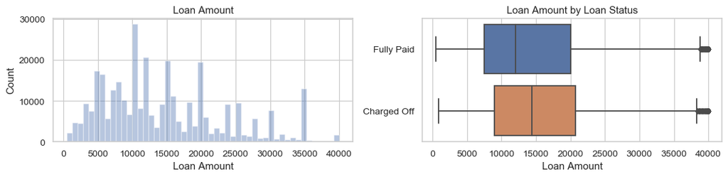

```python
plot_var('loan_amnt', 'Loan Amount', continuous=True)
```

Charged-off Los préstamos tienden a tener montos de préstamos más altos. Comparemos las estadísticas resumidas por estado del préstamo:

```python
loans.groupby('loan_status')['loan_amnt'].describe().round(2)
```

| loan_status | count | mean | std | min | 25% | 50% | 75% | max |
| --- | --- | --- | --- | --- | --- | --- | --- | --- |
| Charged Off | 71616.0 | 15646.32 | 8876.17 | 900.0 | 9000.0 | 14400.0 | 20725.0 | 40000.0 |
| Fully Paid | 260404.0 | 14106.30 | 8638.21 | 500.0 | 7500.0 | 12000.0 | 20000.0 | 40000.0 |

## 5.3 "term"

Data Dictionary: "El número de pagos del préstamo. Los valores están en meses y pueden ser 36 o 60 meses".

```python
loans['term'].value_counts(dropna=False)
```

```
 36 months    250534
 60 months     81486
Name: term, dtype: int64
```

Podemos observar que la cantidad de prestamos a 3 años es superior, a la de 5 años.

Convertimos `term` a enteros.

```python
loans['term'] = loans['term'].apply(lambda s: np.int8(s.split()[0]))
```

```python
loans['term'].value_counts(normalize=True)
```

```
36    0.754575
60    0.245425
Name: term, dtype: float64
```

Comparamos charge-off por período de préstamo:

```python
loans.groupby('term')['loan_status'].value_counts(normalize=True).loc[:,'Charged Off']
```

```
term
36    0.172643
60    0.348072
Name: loan_status, dtype: float64
```

Alrededor del 76% de los préstamos completados tienen períodos de tres años, y el resto tiene períodos de cinco años. Los préstamos con períodos de cinco años tienen más del doble de probabilidades de amortizarse que los préstamos con períodos de tres años.

## 5.4 int_rate

Data Dictionary: "Tasa de interés del préstamo."

```python
loans['int_rate'].describe().round(2)
```

```
count    332020.00
mean         13.30
std           4.77
min           5.31
25%           9.76
50%          12.79
75%          16.02
max          30.99
Name: int_rate, dtype: float64
```

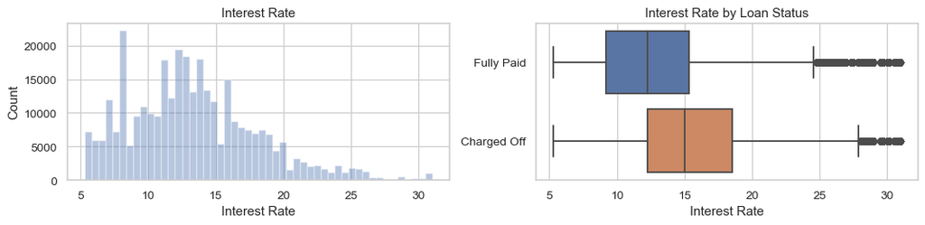

```python
plot_var('int_rate', 'Interest Rate', continuous=True)
```

Los préstamos cancelados tienden a tener tasas de interés mucho más altas. Comparemos las estadísticas resumidas por estado del préstamo:

```python
loans.groupby('loan_status')['int_rate'].describe().round(2)
```

| loan_status | count | mean | std | min | 25% | 50% | 75% | max |
| --- | --- | --- | --- | --- | --- | --- | --- | --- |
| Charged Off | 71616.0 | 15.71 | 4.94 | 5.31 | 12.29 | 15.04 | 18.55 | 30.99 |
| Fully Paid | 260404.0 | 12.64 | 4.51 | 5.31 | 9.17 | 12.29 | 15.31 | 30.99 |

## 5.5 installment

Data Dictionary: "El pago mensual adeudado por el prestatario si el préstamo se origina.."

```python
loans['installment'].describe().round(2)
```

```
count    332020.00
mean        438.31
std         261.22
min          15.69
25%         249.30
50%         375.43
75%         579.96
max        1719.83
Name: installment, dtype: float64
```

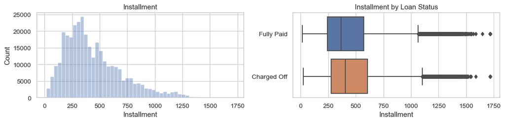

```python
plot_var('installment', 'Installment', continuous=True)
```

Charged-off loans tienden a tener cuotas más altas. Comparemos las estadísticas resumidas por estado del préstamo:

```python
loans.groupby('loan_status')['installment'].describe().round(2)
```

| loan_status | count | mean | std | min | 25% | 50% | 75% | max |
| --- | --- | --- | --- | --- | --- | --- | --- | --- |
| Charged Off | 71616.0 | 466.72 | 264.00 | 21.62 | 276.06 | 403.30 | 607.62 | 1717.63 |
| Fully Paid | 260404.0 | 430.50 | 259.91 | 15.69 | 240.92 | 368.08 | 571.20 | 1719.83 |

## 5.6 grade, sub_grade

Data Dictionary for `grade`: "LendingClub calificacion del préstamo asignado."

Data Dictionary for `sub_grade`: "LendingClub sub-calificacion del préstamo asignado."

Que posibles valores podrian tener `grade` y `sub_grade`?

```python
print(sorted(loans['grade'].unique()))
```

```
['A', 'B', 'C', 'D', 'E', 'F', 'G']
```

```python
print(sorted(loans['sub_grade'].unique()))
```

```
['A1', 'A2', 'A3', 'A4', 'A5', 'B1', 'B2', 'B3', 'B4', 'B5', 'C1', 'C2', 'C3', 'C4', 'C5', 'D1', 'D2', 'D3', 'D4', 'D5', 'E1', 'E2', 'E3', 'E4', 'E5', 'F1', 'F2', 'F3', 'F4', 'F5', 'G1', 'G2', 'G3', 'G4', 'G5']
```

La calificación está implícita en la subrasante, así que dejemos caer la columna de calificación.

```python
loans.drop('grade', axis=1, inplace=True)
```

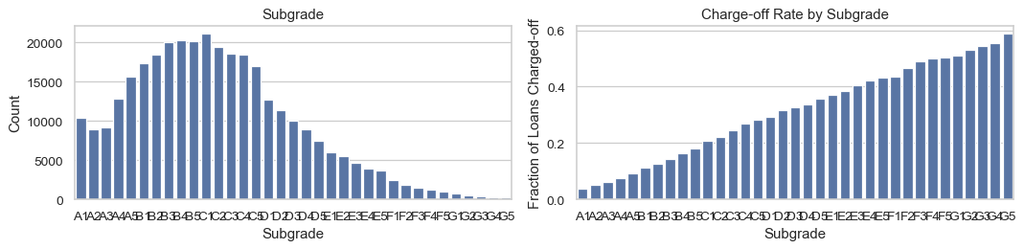

```python
plot_var('sub_grade', 'Subgrade', continuous=False)
```

Vemos como se conceden muy pocos prestamos de alto riesgo, y sin embargo son esos prestamos de alto riesgo los que presentan mayor índice de impago.

En cambio podemos observar que se conceden muchos prestamos de riesgo bajo y medio, en estos los impagos son más bajos.

## 5.7 emp_title

Data Dictionary: "El título del trabajo proporcionado por el Prestatario al solicitar el préstamo.."

```python
loans['emp_title'].describe()
```

```
count      310775
unique     121292
top       Teacher
freq         5324
Name: emp_title, dtype: object
```

Hay demasiados títulos de trabajo diferentes para que esta característica sea útil, por lo que la descartamos.

```python
loans.drop(labels='emp_title', axis=1, inplace=True)
```

## 5.8 emp_length

Data Dictionary: "Duración del empleo en años. Los valores posibles están entre 0 y 10, donde 0 significa menos de un año y 10 significa diez o más años ". Los datos reales no coinciden con esta descripción:

```python
loans['emp_length'].value_counts(dropna=False).sort_index()
```

```
1 year        22042
10+ years    108974
2 years       29930
3 years       26404
4 years       20138
5 years       20835
6 years       15394
7 years       14743
8 years       14988
9 years       12613
< 1 year      26601
NaN           19358
Name: emp_length, dtype: int64
```

Convierta `emp_length` a enteros:

```python
loans['emp_length'].replace(to_replace='10+ years', value='10 years', inplace=True)
```

```python
loans['emp_length'].replace('< 1 year', '0 years', inplace=True)
```

```python
def emp_length_to_int(s):
    if pd.isnull(s):
        return s
    else:
        return np.int8(s.split()[0])
```

```python
loans['emp_length'] = loans['emp_length'].apply(emp_length_to_int)
```

```python
loans['emp_length'].value_counts(dropna=False).sort_index()
```

```
0.0      26601
1.0      22042
2.0      29930
3.0      26404
4.0      20138
5.0      20835
6.0      15394
7.0      14743
8.0      14988
9.0      12613
10.0    108974
NaN      19358
Name: emp_length, dtype: int64
```

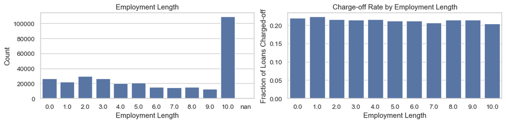

```python
plot_var('emp_length', 'Employment Length', continuous=False)
```

El estado del préstamo no parece variar mucho con la duración del empleo en promedio, excepto por una pequeña caída en las cancelaciones para prestatarios con más de 10 años de empleo.

## 5.9 home_ownership

Data Dictionary: "El estado de propiedad de la vivienda proporcionado por el prestatario durante el registro u obtenido del informe de crédito. Nuestros valores son: ALQUILER, PROPIO, HIPOTECA, OTROS."

```python
loans['home_ownership'].value_counts(dropna=False)
```

```
MORTGAGE    164196
RENT        132074
OWN          35624
ANY             74
OTHER           41
NONE            11
Name: home_ownership, dtype: int64
```

Remplazamos los valores `ANY` and `NONE` with `OTHER`:

```python
loans['home_ownership'].replace(['NONE', 'ANY'], 'OTHER', inplace=True)
```

```python
loans['home_ownership'].value_counts(dropna=False)
```

```
MORTGAGE    164196
RENT        132074
OWN          35624
OTHER          126
Name: home_ownership, dtype: int64
```

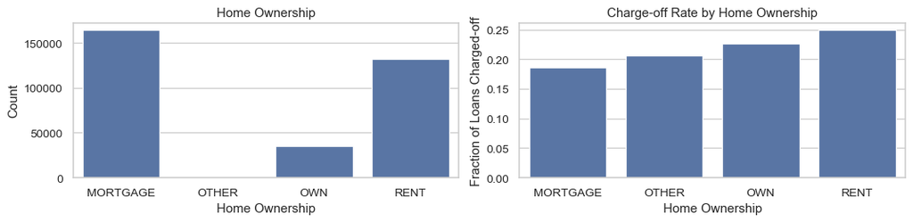

```python
plot_var('home_ownership', 'Home Ownership', continuous=False)
```

Parece haber grandes diferencias en las tasas de descuento por estado de propiedad de la vivienda. Los inquilinos y propietarios tienen una mayor probabilidad de cancelación. Comparemos las tasas de descuento:

```python
loans.groupby('home_ownership')['loan_status'].value_counts(normalize=True).loc[:,'Charged Off']
```

```
home_ownership
MORTGAGE    0.186618
OTHER       0.206349
OWN         0.225747
RENT        0.249148
Name: loan_status, dtype: float64
```

## 5.10 annual_inc

Data Dictionary: "El ingreso anual autoinformado proporcionado por el prestatario durante el registro."

```python
loans['annual_inc'].describe().round()
```

```
count     332020.0
mean       75932.0
std        62470.0
min            0.0
25%        45600.0
50%        65000.0
75%        90000.0
max      9000000.0
Name: annual_inc, dtype: float64
```

```python
loans['log_annual_inc'] = loans['annual_inc'].apply(lambda x: np.log10(x+1))
```

```python
loans.drop('annual_inc', axis=1, inplace=True)
```

```python
loans['log_annual_inc'].describe().round()
```

```
count    332020.0
mean          5.0
std           0.0
min           0.0
25%           5.0
50%           5.0
75%           5.0
max           7.0
Name: log_annual_inc, dtype: float64
```

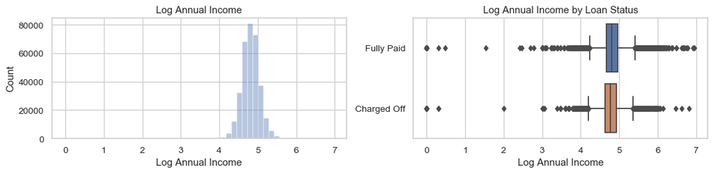

```python
plot_var('log_annual_inc', 'Log Annual Income', continuous=True)
```

Parece que las personas con mayores ingresos tienen más probabilidades de pagar sus préstamos. Comparemos las estadísticas resumidas por estado del préstamo:

Podria darse el caso, de personas con grandes ingresos, y con tendencia la morosidad.

```python
loans.groupby('loan_status')['log_annual_inc'].describe().round()
```

| loan_status | count | mean | std | min | 25% | 50% | 75% | max |
| --- | --- | --- | --- | --- | --- | --- | --- | --- |
| Charged Off | 71616.0 | 5.0 | 0.0 | 0.0 | 5.0 | 5.0 | 5.0 | 7.0 |
| Fully Paid | 260404.0 | 5.0 | 0.0 | 0.0 | 5.0 | 5.0 | 5.0 | 7.0 |

## 5.11 verification_status

Data Dictionary: "Indica si los ingresos fueron verificados por [Lending Club], o verificados, o si la fuente de ingresos fue verificada ".

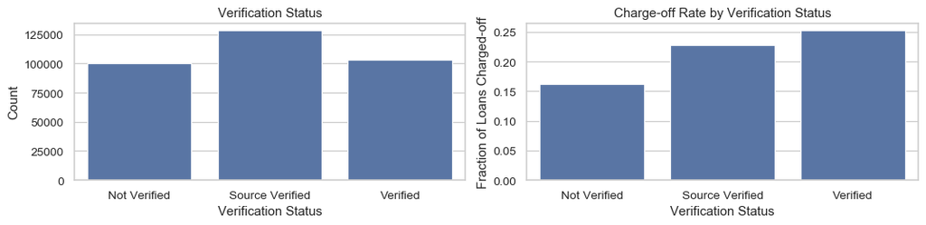

```python
plot_var('verification_status', 'Verification Status', continuous=False)
```

## 5.12 issue_d

Data Dictionary: "El mes en que se financió el préstamo.."

## 5.13 purpose

Data Dictionary: "Una categoría proporcionada por el prestatario para la solicitud de préstamo.."

```python
loans['purpose'].value_counts()
```

```
debt_consolidation    192874
credit_card            72508
home_improvement       21465
other                  19285
major_purchase          7256
small_business          3829
medical                 3806
car                     3651
moving                  2330
vacation                2296
house                   1821
wedding                  583
renewable_energy         222
educational               94
Name: purpose, dtype: int64
```

Calcule las tasas de descuento por propósito:

```python
loans.groupby('purpose')['loan_status'].value_counts(normalize=True).loc[:,'Charged Off'].sort_values().round(2)
```

```
purpose
wedding               0.10
car                   0.15
educational           0.17
credit_card           0.19
renewable_energy      0.19
home_improvement      0.19
vacation              0.21
major_purchase        0.21
debt_consolidation    0.23
other                 0.23
medical               0.24
moving                0.24
house                 0.25
small_business        0.32
Name: loan_status, dtype: float64
```

## 5.14 title

Data Dictionary: "El título del préstamo proporcionado por el prestatario.."

```python
loans['title'].describe()
```

```
count                 328143
unique                 19161
top       Debt consolidation
freq                  163086
Name: title, dtype: object
```

Vea los 10 títulos de préstamo principales y sus frecuencias:

```python
loans['title'].value_counts().head(10)
```

```
Debt consolidation         163086
Credit card refinancing     61266
Home improvement            18287
Other                       16405
Major purchase               5873
Debt Consolidation           3962
Medical expenses             3308
Business                     2864
Car financing                2780
Vacation                     2041
Name: title, dtype: int64
```

```python
loans.drop('title', axis=1, inplace=True)
```

## 5.15 zip_code, addr_state

Data Dictionary for `zip_code`: "Los primeros 3 números del código postal proporcionados por el prestatario en la solicitud de préstamo ".

Data Dictionary for `addr_state`: "El estado proporcionado por el prestatario en la solicitud de préstamo."

```python
loans['zip_code'].sample(5)
```

```
19008     450xx
80445     201xx
226892    900xx
257112    615xx
164695    840xx
Name: zip_code, dtype: object
```

```python
loans['zip_code'].nunique()
```

```
906
```

```python
loans['addr_state'].sample(5)
```

```
177186    AK
136080    CT
106266    NY
282996    GA
205542    NJ
Name: addr_state, dtype: object
```

```python
loans['addr_state'].nunique()
```

```
51
```

Hay muchos códigos postales diferentes, así que mantengamos la columna de estado.

```python
loans.drop(labels='zip_code', axis=1, inplace=True)
```

Calcule las Charged Off por estado de dirección:

```python
loans.groupby('addr_state')['loan_status'].value_counts(normalize=True).loc[:,'Charged Off'].sort_values().round(2)
```

```
addr_state
DC    0.15
VT    0.15
OR    0.15
WV    0.15
WY    0.16
NH    0.16
ME    0.17
SC    0.17
RI    0.17
UT    0.17
MT    0.17
WA    0.18
CO    0.18
KS    0.18
CT    0.19
AK    0.19
GA    0.19
IL    0.20
AZ    0.20
WI    0.20
MA    0.21
TX    0.21
CA    0.21
HI    0.21
MN    0.21
ID    0.22
VA    0.22
MI    0.22
NJ    0.22
DE    0.22
NC    0.22
SD    0.22
PA    0.23
OH    0.23
MO    0.23
IN    0.23
TN    0.23
LA    0.23
NV    0.23
MD    0.24
FL    0.24
KY    0.24
NY    0.24
IA    0.25
NM    0.25
AL    0.25
AR    0.26
OK    0.26
NE    0.27
ND    0.27
MS    0.28
Name: loan_status, dtype: float64
```

## 5.16 dti

Data Dictionary: "Proporción calculada usando los pagos mensuales totales de la deuda del prestatario sobre las obligaciones totales de la deuda, excluyendo la hipoteca y el préstamo LC solicitado, dividido por el ingreso mensual autoinformado del prestatario".

```python
loans['dti'].describe().round(2)
```

```
count    331934.00
mean         18.29
std          11.68
min           0.00
25%          11.80
50%          17.61
75%          24.04
max         999.00
Name: dti, dtype: float64
```

Hay varios valores atípicos que arruinan nuestras tramas predeterminadas. Trace un histograma para `dti` menor que 60:

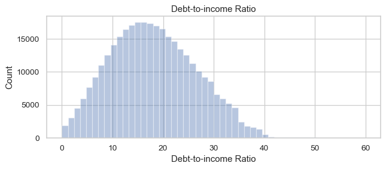

```python
plt.figure(figsize=(8,3), dpi=90)
sns.distplot(loans.loc[loans['dti'].notnull() & (loans['dti']<60), 'dti'], kde=False)
plt.xlabel('Debt-to-income Ratio')
plt.ylabel('Count')
plt.title('Debt-to-income Ratio')
```

¿Cuántos de los valores `dti` son" valores atípicos "(superiores a 60)?

```python
(loans['dti']>=60).sum()
```

```
445
```

Muy pocos. Compare las estadísticas resumidas por estado del préstamo:

```python
loans.groupby('loan_status')['dti'].describe()
```

| loan_status | count | mean | std | min | 25% | 50% | 75% | max |
| --- | --- | --- | --- | --- | --- | --- | --- | --- |
| Charged Off | 71594.0 | 20.126217 | 12.235279 | 0.0 | 13.45 | 19.68 | 26.2375 | 999.0 |
| Fully Paid | 260340.0 | 17.783804 | 11.474780 | 0.0 | 11.41 | 17.08 | 23.3800 | 999.0 |

Los préstamos terminados que se cargan tienden a tener una mayor relación deuda / ingreso.

## 5.17 earliest_cr_line

Data Dictionary: "El mes en que se abrió la primera línea de crédito informada del prestatario."

```python
loans['earliest_cr_line'].sample(5)
```

```
140303    Oct-1997
146841    Oct-2010
5805      Jan-2012
88287     Aug-1989
260379    Feb-2002
Name: earliest_cr_line, dtype: object
```

```python
loans['earliest_cr_line'].isnull().any()
```

```
True
```

Solo conservamos el año por simplicidad:

```python
loans['earliest_cr_line'] = loans['earliest_cr_line'].apply(lambda s: int(s[-4:]))
```

```python
loans['earliest_cr_line'].describe().round(2)
```

```
count    300418.00
mean       1999.07
std           7.33
min        1944.00
25%        1995.00
50%        2000.00
75%        2004.00
max        2015.00
Name: earliest_cr_line, dtype: float64
```

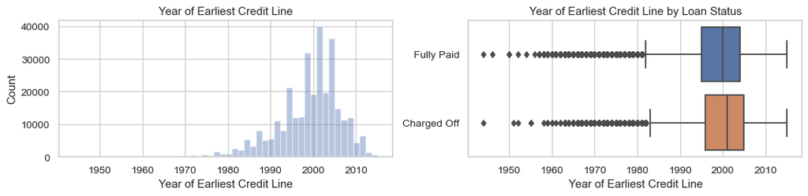

```python
plot_var('earliest_cr_line', 'Year of Earliest Credit Line', continuous=True)
```

Los prestatarios a quienes se les aplica un cobro tienden a tener líneas de crédito más cortas.

## 5.18 open_acc

Data Dictionary: "El número de líneas de crédito abiertas en el archivo de crédito del prestatario."

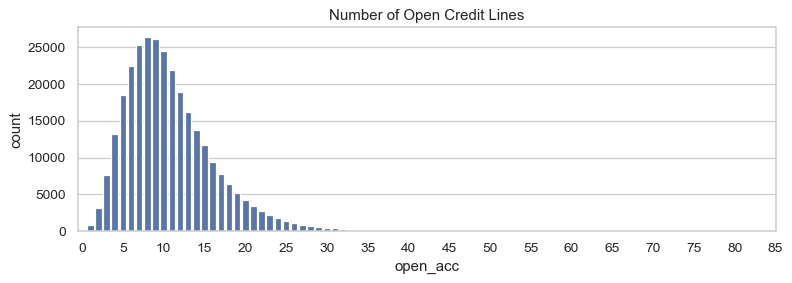

```python
plt.figure(figsize=(10,3), dpi=90)
sns.countplot(loans['open_acc'], order=sorted(loans['open_acc'].unique()), color='#5975A4', saturation=1)
_, _ = plt.xticks(np.arange(0, 90, 5), np.arange(0, 90, 5))
plt.title('Number of Open Credit Lines')
```

¿Existe alguna diferencia en el número de líneas de crédito entre préstamos totalmente pagados y préstamos cancelados?

```python
loans.groupby('loan_status')['open_acc'].describe()
```

| loan_status | count | mean | std | min | 25% | 50% | 75% | max |
| --- | --- | --- | --- | --- | --- | --- | --- | --- |
| Charged Off | 64235.0 | 12.090589 | 5.684062 | 1.0 | 8.0 | 11.0 | 15.0 | 68.0 |
| Fully Paid | 236183.0 | 11.664129 | 5.452840 | 1.0 | 8.0 | 11.0 | 14.0 | 81.0 |

No parece haber una diferencia significativa.

## 5.19 pub_rec

Data Dictionary: "Número de registros públicos despectivos."

```python
loans['pub_rec'].value_counts().sort_index()
```

```
0.0     249918
1.0      42155
2.0       5418
3.0       1727
4.0        597
5.0        281
6.0        149
7.0         80
8.0         39
9.0         19
10.0        11
11.0         6
12.0         4
13.0         5
14.0         1
15.0         2
16.0         1
19.0         2
21.0         1
24.0         1
61.0         1
Name: pub_rec, dtype: int64
```

¿Existe alguna diferencia en los registros públicos promedio entre préstamos totalmente pagados y préstamos cancelados?

```python
loans.groupby('loan_status')['pub_rec'].describe()
```

| loan_status | count | mean | std | min | 25% | 50% | 75% | max |
| --- | --- | --- | --- | --- | --- | --- | --- | --- |
| Charged Off | 64235.0 | 0.243154 | 0.656510 | 0.0 | 0.0 | 0.0 | 0.0 | 61.0 |
| Fully Paid | 236183.0 | 0.206518 | 0.572163 | 0.0 | 0.0 | 0.0 | 0.0 | 24.0 |

## 5.20 revol_bal

Data Dictionary: "Saldo rotativo total de crédito."

```python
loans['revol_bal'].describe().round(2)
```

[output not shown]

Hacemos la transformacion Logaritmica:

```python
loans['log_revol_bal'] = loans['revol_bal'].apply(lambda x: np.log10(x+1))
```

```python
loans.drop('revol_bal', axis=1, inplace=True)
```

```python
plot_var('log_revol_bal', 'Log Revolving Credit Balance', continuous=True)
```

[output not shown]

```python
loans.groupby('loan_status')['log_revol_bal'].describe()
```

[output not shown]

## 5.21 revol_util

Data Dictionary: "Tasa de utilización de línea rotativa, o la cantidad de crédito que el prestatario está usando en relación con todo el crédito rotativo disponible."

```python
loans['revol_util'].describe().round(2)
```

```
count    300418.00
mean         52.15
std          24.30
min           0.00
25%          34.00
50%          52.60
75%          70.90
max         177.70
Name: revol_util, dtype: float64
```

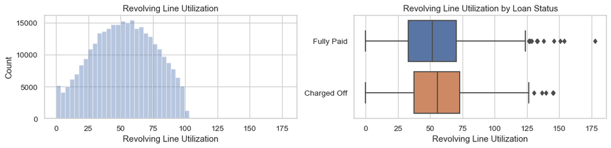

```python
plot_var('revol_util', 'Revolving Line Utilization', continuous=True)
```

```python
loans.groupby('loan_status')['revol_util'].describe().round(2)
```

| loan_status | count | mean | std | min | 25% | 50% | 75% | max |
| --- | --- | --- | --- | --- | --- | --- | --- | --- |
| Charged Off | 64235.0 | 54.67 | 23.80 | 0.0 | 37.4 | 55.5 | 73.0 | 145.6 |
| Fully Paid | 236183.0 | 51.47 | 24.39 | 0.0 | 33.1 | 51.7 | 70.3 | 177.7 |

## 5.22 total_acc

Data Dictionary: "El número total de líneas de crédito actualmente en el archivo de crédito del prestatario ."

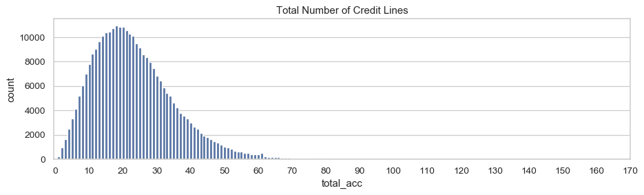

```python
plt.figure(figsize=(12,3), dpi=90)
sns.countplot(loans['total_acc'], order=sorted(loans['total_acc'].unique()), color='#5975A4', saturation=1)
_, _ = plt.xticks(np.arange(0, 176, 10), np.arange(0, 176, 10))
plt.title('Total Number of Credit Lines')
```

```python
loans.groupby('loan_status')['total_acc'].describe().round(2)
```

| loan_status | count | mean | std | min | 25% | 50% | 75% | max |
| --- | --- | --- | --- | --- | --- | --- | --- | --- |
| Charged Off | 64235.0 | 24.86 | 12.15 | 2.0 | 16.0 | 23.0 | 32.0 | 118.0 |
| Fully Paid | 236183.0 | 25.26 | 11.98 | 2.0 | 16.0 | 24.0 | 32.0 | 127.0 |

No hay grandes diferencias aquí.

## 5.23 initial_list_status

Data Dictionary: "El estado de listado inicial del préstamo. Los valores posibles son - W, F.

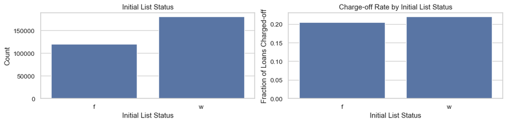

```python
plot_var('initial_list_status', 'Initial List Status', continuous=False)
```

## 5.24 application_type

Data Dictionary: "Indica si el préstamo es una solicitud individual o una solicitud conjunta con dos coprestatarios."

```python
loans['application_type'].value_counts()
```

```
Individual    294985
Joint App       5433
Name: application_type, dtype: int64
```

Simplemente comparamos las tasas de descuento por tipo de aplicación:

```python
loans.groupby('application_type')['loan_status'].value_counts(normalize=True).loc[:,'Charged Off'].round(2)
```

```
application_type
Individual    0.21
Joint App     0.30
Name: loan_status, dtype: float64
```

## 5.25 mort_acc

Data Dictionary: "Cantidad de cuentas hipotecarias."

```python
loans['mort_acc'].describe().round(2)
```

```
count    300418.00
mean          1.66
std           2.00
min           0.00
25%           0.00
50%           1.00
75%           3.00
max          47.00
Name: mort_acc, dtype: float64
```

```python
loans['mort_acc'].value_counts().head(10)
```

```
0.0    121893
1.0     52449
2.0     43641
3.0     32242
4.0     21669
5.0     13103
6.0      7436
7.0      3852
8.0      1976
9.0      1008
Name: mort_acc, dtype: int64
```

Compare las estadísticas resumidas por estado del préstamo:

```python
loans.groupby('loan_status')['mort_acc'].describe()
```

| loan_status | count | mean | std | min | 25% | 50% | 75% | max |
| --- | --- | --- | --- | --- | --- | --- | --- | --- |
| Charged Off | 64235.0 | 1.355071 | 1.816065 | 0.0 | 0.0 | 1.0 | 2.0 | 29.0 |
| Fully Paid | 236183.0 | 1.742564 | 2.035130 | 0.0 | 0.0 | 1.0 | 3.0 | 47.0 |

Las personas que pagan sus préstamos tienen más probabilidades de tener varias cuentas hipotecarias.

## 5.26 pub_rec_bankruptcies

Data Dictionary: "Número de quiebras de registros públicos."

```python
loans['pub_rec_bankruptcies'].value_counts().sort_index()
```

```
0.0    263529
1.0     34636
2.0      1734
3.0       369
4.0       102
5.0        33
6.0        11
7.0         3
8.0         1
Name: pub_rec_bankruptcies, dtype: int64
```

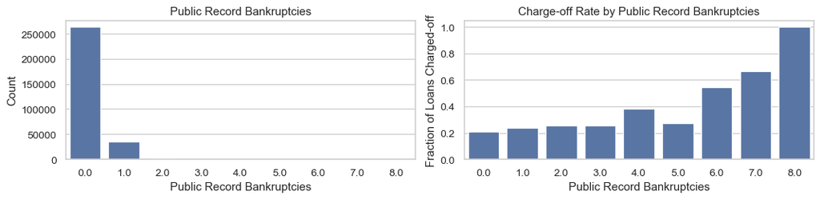

```python
plot_var('pub_rec_bankruptcies', 'Public Record Bankruptcies', continuous=False)
```

```python
loans.head(5)
```

|  | loan_amnt | term | int_rate | installment | sub_grade | emp_length | home_ownership | verification_status | purpose | addr_state | dti | earliest_cr_line | open_acc | pub_rec | revol_util | total_acc | initial_list_status | application_type | mort_acc | pub_rec_bankruptcies | loan_status | log_annual_inc | log_revol_bal |
| --- | --- | --- | --- | --- | --- | --- | --- | --- | --- | --- | --- | --- | --- | --- | --- | --- | --- | --- | --- | --- | --- | --- | --- |
| 0 | 20000 | 36 | 9.49 | 640.57 | B2 | 3.0 | RENT | Source Verified | credit_card | NJ | 10.89 | 2009 | 9.0 | 0.0 | 70.2 | 14.0 | w | Individual | 0.0 | 0.0 | Fully Paid | 5.079185 | 4.438685 |
| 1 | 2500 | 36 | 11.47 | 82.41 | B5 | 6.0 | RENT | Source Verified | credit_card | TX | 17.35 | 2005 | 5.0 | 0.0 | 10.7 | 19.0 | w | Individual | 0.0 | 0.0 | Fully Paid | 4.544080 | 3.507451 |
| 2 | 17825 | 36 | 17.99 | 644.33 | D2 | 3.0 | RENT | Source Verified | debt_consolidation | IN | 16.87 | 2006 | 15.0 | 0.0 | 38.5 | 38.0 | f | Individual | 0.0 | 0.0 | Charged Off | 5.075551 | 3.499962 |
| 3 | 9500 | 36 | 8.18 | 298.49 | B1 | 7.0 | MORTGAGE | Source Verified | credit_card | AZ | 24.69 | 2003 | 15.0 | 0.0 | 38.9 | 27.0 | w | Individual | 1.0 | 0.0 | Fully Paid | 4.913819 | 4.050380 |
| 4 | 15000 | 36 | 12.49 | 501.74 | B4 | 10.0 | RENT | Source Verified | debt_consolidation | TX | 13.65 | 1988 | 11.0 | 1.0 | 63.3 | 16.0 | f | Individual | 0.0 | 1.0 | Charged Off | 4.821435 | 4.089411 |

# 6.- Preprocesamiento de datos

Volvemos a ver el porcentaje de valores ausentes en cada variable que tenemos

```python
missing_fractions2 = loans.isnull().mean().sort_values(ascending=False)
```

```python
missing_fractions2.head(20)
```

[output not shown]

Vemos que hay pocas observaciones con datos ausentes, por lo que vamos a eliminar estas observaciones

```python
loans = loans.dropna()
```

Vemos otra vez los porcentajes de NaN

```python
missing_fractions3 = loans.isnull().mean().sort_values(ascending=False)
```

```python
missing_fractions3.head(20)
```

```
log_revol_bal          0.0
dti                    0.0
term                   0.0
int_rate               0.0
installment            0.0
sub_grade              0.0
emp_length             0.0
home_ownership         0.0
verification_status    0.0
purpose                0.0
addr_state             0.0
earliest_cr_line       0.0
log_annual_inc         0.0
open_acc               0.0
pub_rec                0.0
revol_util             0.0
total_acc              0.0
initial_list_status    0.0
application_type       0.0
mort_acc               0.0
dtype: float64
```

```python
## Escalamos las variables numericas
```

```python
## Creamos dataframe con las variables numericas y otro con las categóricas
```

```python
loans_numericas = pd.DataFrame(loans, columns= ["loan_amnt","term","int_rate","installment","emp_length","dti","earliest_cr_line","open_acc","pub_rec","revol_util","total_acc","mort_acc","pub_rec_bankruptcies","log_annual_inc","log_revol_bal"])

loans_categoricas = pd.DataFrame(loans, columns=["loan_status", 'home_ownership', 'verification_status', 'purpose', 'initial_list_status', 'application_type', 'sub_grade'])
```

```python
from sklearn import preprocessing
from sklearn.preprocessing import StandardScaler

scaler = preprocessing.RobustScaler()

numericas_escaladas = scaler.fit_transform(loans_numericas)
numericas_escaladas = pd.DataFrame(numericas_escaladas, columns = [loans_numericas])
```

## 6.1 Convertimos loan status en dummies.

Cambiamos la variable `loan_status` a una variable dummie 0/1 , 0 es fully paid y 1 charge-off:

Llamamos a la variable charged_off

```python
loans_categoricas['charged_off'] = (loans_categoricas['loan_status'] == 'Charged Off').apply(np.uint8)
loans_categoricas.drop('loan_status', axis=1, inplace=True)
```

## 6.2 Creamos Dummies para las variables Categoricas.

```python
#Creamos Dummies:

#Eliminamos algunas variable más: addr_state (porque es una variable discriminante)


loans_categoricas = pd.get_dummies(loans_categoricas, columns=[ 'home_ownership', 'verification_status', 'sub_grade', 'purpose', 'initial_list_status', 'application_type'], drop_first=True)
```

```python
loans_categoricas.head(5)
```

|  | charged_off | home_ownership_OTHER | home_ownership_OWN | home_ownership_RENT | verification_status_Source Verified | verification_status_Verified | sub_grade_A2 | sub_grade_A3 | sub_grade_A4 | sub_grade_A5 | sub_grade_B1 | sub_grade_B2 | sub_grade_B3 | sub_grade_B4 | sub_grade_B5 | sub_grade_C1 | sub_grade_C2 | sub_grade_C3 | sub_grade_C4 | sub_grade_C5 | sub_grade_D1 | sub_grade_D2 | sub_grade_D3 | sub_grade_D4 | sub_grade_D5 | sub_grade_E1 | sub_grade_E2 | sub_grade_E3 | sub_grade_E4 | … |
| --- | --- | --- | --- | --- | --- | --- | --- | --- | --- | --- | --- | --- | --- | --- | --- | --- | --- | --- | --- | --- | --- | --- | --- | --- | --- | --- | --- | --- | --- | --- |
| 0 | 0 | 0 | 0 | 1 | 1 | 0 | 0 | 0 | 0 | 0 | 0 | 1 | 0 | 0 | 0 | 0 | 0 | 0 | 0 | 0 | 0 | 0 | 0 | 0 | 0 | 0 | 0 | 0 | 0 | … |
| 1 | 0 | 0 | 0 | 1 | 1 | 0 | 0 | 0 | 0 | 0 | 0 | 0 | 0 | 0 | 1 | 0 | 0 | 0 | 0 | 0 | 0 | 0 | 0 | 0 | 0 | 0 | 0 | 0 | 0 | … |
| 2 | 1 | 0 | 0 | 1 | 1 | 0 | 0 | 0 | 0 | 0 | 0 | 0 | 0 | 0 | 0 | 0 | 0 | 0 | 0 | 0 | 0 | 1 | 0 | 0 | 0 | 0 | 0 | 0 | 0 | … |
| 3 | 0 | 0 | 0 | 0 | 1 | 0 | 0 | 0 | 0 | 0 | 1 | 0 | 0 | 0 | 0 | 0 | 0 | 0 | 0 | 0 | 0 | 0 | 0 | 0 | 0 | 0 | 0 | 0 | 0 | … |
| 4 | 1 | 0 | 0 | 1 | 1 | 0 | 0 | 0 | 0 | 0 | 0 | 0 | 0 | 1 | 0 | 0 | 0 | 0 | 0 | 0 | 0 | 0 | 0 | 0 | 0 | 0 | 0 | 0 | 0 | … |

```python
loans_categoricas.index = range(loans_categoricas.shape[0])
```

## 6.3- Juntamos los dos DataFrames: Categoricas + Numericas.

```python
loans_lasso = pd.concat([numericas_escaladas,loans_categoricas], axis = 1)
```

```python
loans_lasso.isnull().sum()
```

```
(loan_amnt,)                           0
(term,)                                0
(int_rate,)                            0
(installment,)                         0
(emp_length,)                          0
(dti,)                                 0
(earliest_cr_line,)                    0
(open_acc,)                            0
(pub_rec,)                             0
(revol_util,)                          0
(total_acc,)                           0
(mort_acc,)                            0
(pub_rec_bankruptcies,)                0
(log_annual_inc,)                      0
(log_revol_bal,)                       0
charged_off                            0
home_ownership_OTHER                   0
home_ownership_OWN                     0
home_ownership_RENT                    0
verification_status_Source Verified    0
verification_status_Verified           0
sub_grade_A2                           0
sub_grade_A3                           0
sub_grade_A4                           0
sub_grade_A5                           0
sub_grade_B1                           0
sub_grade_B2                           0
sub_grade_B3                           0
sub_grade_B4                           0
sub_grade_B5                           0
sub_grade_C1                           0
sub_grade_C2                           0
sub_grade_C3                           0
sub_grade_C4                           0
sub_grade_C5                           0
sub_grade_D1                           0
sub_grade_D2                           0
sub_grade_D3                           0
sub_grade_D4                           0
sub_grade_D5                           0
```

[output cut: 15 more lines]

```
purpose_credit_card                    0
purpose_debt_consolidation             0
purpose_home_improvement               0
purpose_house                          0
purpose_major_purchase                 0
purpose_medical                        0
purpose_moving                         0
purpose_other                          0
purpose_renewable_energy               0
purpose_small_business                 0
purpose_vacation                       0
purpose_wedding                        0
initial_list_status_w                  0
application_type_Joint App             0
dtype: int64
```

## 7.- Modelo Lasso

```python
#Cargamos librerias:

from sklearn import linear_model
from sklearn.linear_model import LassoCV
from sklearn.datasets import make_regression
from sklearn.linear_model import LinearRegression
from sklearn.linear_model import Lasso
from sklearn.metrics import mean_squared_error
from sklearn.metrics import r2_score
```

```python
from sklearn.linear_model import LassoCV
from sklearn.metrics import mean_squared_error




endogena = ['charged_off']
# exógenas
exogenas = list(set(list(loans_lasso.columns))-set(endogena))
X = loans_lasso[exogenas].values
Y = loans_lasso[endogena].values

lassocv = LassoCV(alphas = None, cv = 10, max_iter = 100)
lassocv.fit(X, Y)
lassocv.alpha_
model_lasso = Lasso(alpha=lassocv.alpha_) # lasso function
model_lasso.fit(X, Y)
```

[output not shown]

[output cut: 243 more lines]

[output not shown]

```
Lasso(alpha=8.397587062047107e-05, copy_X=True, fit_intercept=True,
      max_iter=1000, normalize=False, positive=False, precompute=False,
      random_state=None, selection='cyclic', tol=0.0001, warm_start=False)
```

```python
#Coeficientes del modelo lasso
model_lasso.coef_
coeficientes_lasso = pd.DataFrame(model_lasso.coef_)
```

```python
coeficientes_lasso
```

|  | 0 |
| --- | --- |
| 0 | -0.000000 |
| 1 | -0.014964 |
| 2 | 0.000000 |
| 3 | 0.000000 |
| 4 | 0.007731 |
| 5 | -0.016479 |
| 6 | 0.084945 |
| 7 | 0.021459 |
| 8 | 0.019949 |
| 9 | 0.021667 |
| 10 | -0.040822 |
| 11 | 0.011425 |
| 12 | 0.000000 |
| 13 | -0.000000 |
| 14 | -0.000000 |
| 15 | 0.018904 |
| 16 | 0.006662 |
| 17 | 0.009878 |
| 18 | 0.000000 |
| 19 | 0.005299 |
| 20 | 0.000966 |
| 21 | -0.001701 |
| 22 | 0.125749 |
| 23 | 0.000000 |
| 24 | 0.026049 |
| 25 | 0.004384 |
| 26 | -0.001334 |
| 27 | 0.009188 |
| 28 | -0.019703 |
| 29 | -0.019785 |
| 30 | 0.010721 |
| 31 | 0.004268 |
| 32 | 0.000942 |
| 33 | 0.007045 |
| 34 | 0.000000 |
| 35 | 0.008358 |
| 36 | 0.010181 |
| 37 | 0.013365 |
| 38 | 0.007228 |
| 39 | 0.040154 |
| 40 | -0.014377 |
| 41 | 0.000000 |
| 42 | -0.044097 |
| 43 | 0.000000 |
| 44 | -0.000000 |
| 45 | -0.006700 |
| 46 | 0.003325 |
| 47 | 0.000000 |
| 48 | -0.019752 |
| 49 | 0.022534 |
| 50 | -0.007783 |
| 51 | -0.022477 |
| 52 | -0.000000 |
| 53 | -0.000000 |
| 54 | 0.030087 |
| 55 | -0.015153 |
| 56 | 0.008143 |
| 57 | -0.015091 |
| 58 | -0.017530 |
| 59 | -0.000000 |
| 60 | -0.000987 |
| 61 | 0.064723 |
| 62 | 0.008338 |
| 63 | -0.014408 |
| 64 | 0.063209 |
| 65 | 0.009241 |
| 66 | 0.007953 |
| 67 | 0.014761 |

```python
#Constante
model_lasso.intercept_
```

```
array([0.12719611])
```

```python
#Hacerlo dataframe
coeficientes_lasso.index = loans_lasso.columns[1: ]
coeficientes_lasso.round(3)
```

|  | 0 |
| --- | --- |
| (term,) | -0.000 |
| (int_rate,) | -0.015 |
| (installment,) | 0.000 |
| (emp_length,) | 0.000 |
| (dti,) | 0.008 |
| (earliest_cr_line,) | -0.016 |
| (open_acc,) | 0.085 |
| (pub_rec,) | 0.021 |
| (revol_util,) | 0.020 |
| (total_acc,) | 0.022 |
| (mort_acc,) | -0.041 |
| (pub_rec_bankruptcies,) | 0.011 |
| (log_annual_inc,) | 0.000 |
| (log_revol_bal,) | -0.000 |
| charged_off | -0.000 |
| home_ownership_OTHER | 0.019 |
| home_ownership_OWN | 0.007 |
| home_ownership_RENT | 0.010 |
| verification_status_Source Verified | 0.000 |
| verification_status_Verified | 0.005 |
| sub_grade_A2 | 0.001 |
| sub_grade_A3 | -0.002 |
| sub_grade_A4 | 0.126 |
| sub_grade_A5 | 0.000 |
| sub_grade_B1 | 0.026 |
| sub_grade_B2 | 0.004 |
| sub_grade_B3 | -0.001 |
| sub_grade_B4 | 0.009 |
| sub_grade_B5 | -0.020 |
| sub_grade_C1 | -0.020 |
| sub_grade_C2 | 0.011 |
| sub_grade_C3 | 0.004 |
| sub_grade_C4 | 0.001 |
| sub_grade_C5 | 0.007 |
| sub_grade_D1 | 0.000 |
| sub_grade_D2 | 0.008 |
| sub_grade_D3 | 0.010 |
| sub_grade_D4 | 0.013 |
| sub_grade_D5 | 0.007 |
| sub_grade_E1 | 0.040 |
| sub_grade_E2 | -0.014 |
| sub_grade_E3 | 0.000 |
| sub_grade_E4 | -0.044 |
| sub_grade_E5 | 0.000 |
| sub_grade_F1 | -0.000 |
| sub_grade_F2 | -0.007 |
| sub_grade_F3 | 0.003 |
| sub_grade_F4 | 0.000 |
| sub_grade_F5 | -0.020 |
| sub_grade_G1 | 0.023 |
| sub_grade_G2 | -0.008 |
| sub_grade_G3 | -0.022 |
| sub_grade_G4 | -0.000 |
| sub_grade_G5 | -0.000 |
| purpose_credit_card | 0.030 |
| purpose_debt_consolidation | -0.015 |
| purpose_home_improvement | 0.008 |
| purpose_house | -0.015 |
| purpose_major_purchase | -0.018 |
| purpose_medical | -0.000 |
| purpose_moving | -0.001 |
| purpose_other | 0.065 |
| purpose_renewable_energy | 0.008 |
| purpose_small_business | -0.014 |
| purpose_vacation | 0.063 |
| purpose_wedding | 0.009 |
| initial_list_status_w | 0.008 |
| application_type_Joint App | 0.015 |

```python
model_lasso.coef_.round(2)
```

```
array([-0.  , -0.01,  0.  ,  0.  ,  0.01, -0.02,  0.08,  0.02,  0.02,
        0.02, -0.04,  0.01,  0.  , -0.  , -0.  ,  0.02,  0.01,  0.01,
        0.  ,  0.01,  0.  , -0.  ,  0.13,  0.  ,  0.03,  0.  , -0.  ,
        0.01, -0.02, -0.02,  0.01,  0.  ,  0.  ,  0.01,  0.  ,  0.01,
        0.01,  0.01,  0.01,  0.04, -0.01,  0.  , -0.04,  0.  , -0.  ,
       -0.01,  0.  ,  0.  , -0.02,  0.02, -0.01, -0.02, -0.  , -0.  ,
        0.03, -0.02,  0.01, -0.02, -0.02, -0.  , -0.  ,  0.06,  0.01,
       -0.01,  0.06,  0.01,  0.01,  0.01])
```

### Creamos un DataFrame, con las variables significativas :

```python
loans_2 = pd.concat([numericas_escaladas,loans_categoricas], axis = 1)
```

```python
loans_lasso = pd.DataFrame(loans_2, columns= ["(earliest_cr_line,)","(open_acc,)","(pub_rec,)", "(revol_util,)", "(mort_acc,)",  "(pub_rec_bankruptcies,)","(log_annual_inc,)","(log_revol_bal,)","charged_off", "verification_status_Source Verified", "purpose_credit_card", "purpose_debt_consolidation", "purpose_educational", "purpose_major_purchase", "purpose_moving" , "purpose_other", "purpose_vacation", "purpose_wedding"    ])
```

```python
loans_2.head(5)
```

|  | (loan_amnt,) | (term,) | (int_rate,) | (installment,) | (emp_length,) | (dti,) | (earliest_cr_line,) | (open_acc,) | (pub_rec,) | (revol_util,) | (total_acc,) | (mort_acc,) | (pub_rec_bankruptcies,) | (log_annual_inc,) | (log_revol_bal,) | charged_off | home_ownership_OTHER | home_ownership_OWN | home_ownership_RENT | verification_status_Source Verified | verification_status_Verified | sub_grade_A2 | sub_grade_A3 | sub_grade_A4 | sub_grade_A5 | sub_grade_B1 | sub_grade_B2 | sub_grade_B3 | sub_grade_B4 | … |
| --- | --- | --- | --- | --- | --- | --- | --- | --- | --- | --- | --- | --- | --- | --- | --- | --- | --- | --- | --- | --- | --- | --- | --- | --- | --- | --- | --- | --- | --- | --- |
| 0 | 0.616667 | 0.0 | -0.526316 | 0.763491 | -0.428571 | -0.557283 | 1.000000 | -0.285714 | 0.0 | 0.476965 | -0.5625 | -0.333333 | 0.0 | 0.926985 | 0.743410 | 0 | 0 | 0 | 1 | 1 | 0 | 0 | 0 | 0 | 0 | 0 | 1 | 0 | 0 | … |
| 1 | -0.841667 | 0.0 | -0.210526 | -0.897848 | 0.000000 | -0.028642 | 0.555556 | -0.857143 | 0.0 | -1.135501 | -0.2500 | -0.333333 | 0.0 | -0.935949 | -1.059268 | 0 | 0 | 0 | 1 | 1 | 0 | 0 | 0 | 0 | 0 | 0 | 0 | 0 | 0 | … |
| 2 | 0.435417 | 0.0 | 0.829346 | 0.774682 | -0.428571 | -0.067921 | 0.666667 | 0.571429 | 0.0 | -0.382114 | 0.9375 | -0.333333 | 0.0 | 0.914333 | -1.073766 | 1 | 0 | 0 | 1 | 1 | 0 | 0 | 0 | 0 | 0 | 0 | 0 | 0 | 0 | … |
| 3 | -0.258333 | 0.0 | -0.735247 | -0.254695 | 0.142857 | 0.572013 | 0.333333 | 0.571429 | 0.0 | -0.371274 | 0.2500 | 0.000000 | 0.0 | 0.351274 | -0.008269 | 0 | 0 | 0 | 0 | 1 | 0 | 0 | 0 | 0 | 0 | 1 | 0 | 0 | 0 | … |
| 4 | 0.200000 | 0.0 | -0.047847 | 0.350269 | 0.571429 | -0.331424 | -1.333333 | 0.000000 | 1.0 | 0.289973 | -0.4375 | -0.333333 | 1.0 | 0.029644 | 0.067287 | 1 | 0 | 0 | 1 | 1 | 0 | 0 | 0 | 0 | 0 | 0 | 0 | 0 | 1 | … |

## 8.- Train & Test :

```python
from sklearn.model_selection import train_test_split



endogena = ['charged_off']
# exógenas
exogenas = list(set(list(loans_2.columns))-set(endogena))
x = loans_2[exogenas].values
y = loans_2[endogena].values
```

```python
x_train, x_test, y_train, y_test = train_test_split(x, y, test_size=0.3, random_state=123)
```

```python
#Observamos cuantos 1 obtenemos
loans_2["charged_off"].sum()
```

```
64235
```

```python
from sklearn.utils import resample


#UNDERSAMPLING
df_majority = loans_2[loans_2.charged_off==0]
df_minority = loans_2[loans_2.charged_off==1]# Downsample majority class
df_majority_downsampled = resample(df_majority,
                                 replace=False,    # sample without replacement
                                 n_samples=loans_2["charged_off"].sum(),     # to match minority class
                                 random_state=123) # reproducible results# Combine minority class with downsampled majority class
datos_under = pd.concat([df_majority_downsampled, df_minority])
```

Volvemos a realizar el train y el test una vez que hemos estabilizado

```python
endogena = ['charged_off']
# exógenas
exogenas = list(set(list(datos_under.columns))-set(endogena))
X = datos_under[exogenas].values
Y = datos_under[endogena].values
```

```python
X_train, X_test, Y_train, Y_test = train_test_split(X, Y, test_size=0.3, random_state=123)
```

```python
type(X_train)
```

```
numpy.ndarray
```

```python
datos_under["charged_off"].sum()
```

```
64235
```

Evaluaremos y compararemos los siguientes modelos utilizando un puntaje AUROC con validación cruzada en el conjunto de entrenamiento:

Realizaremos algunos ajustes de hiperparámetros para cada modelo para elegir el modelo más prometedor, luego ajustaremos con más cuidado los hiperparámetros del modelo de mejor rendimiento.

```python
from sklearn.pipeline import Pipeline
from sklearn.discriminant_analysis import LinearDiscriminantAnalysis
from sklearn.model_selection import GridSearchCV
```

```python
from sklearn.linear_model import LogisticRegression
```

## 8.1 - Modificación del dataframe

Tenemos el problema de que al dividir en train y en test, el dataset se ha convertido en un objeto numpy. Queremos por tanto convertirlo de nuevo en un objeto pandas. Procedemos de la siguiente forma

```python
A_train_prueba = pd.DataFrame(X_train)
```

```python
A_train_prueba.head(5)
```

|  | 0 | 1 | 2 | 3 | 4 | 5 | 6 | 7 | 8 | 9 | 10 | 11 | 12 | 13 | 14 | 15 | 16 | 17 | 18 | 19 | 20 | 21 | 22 | 23 | 24 | 25 | 26 | 27 | 28 | … |
| --- | --- | --- | --- | --- | --- | --- | --- | --- | --- | --- | --- | --- | --- | --- | --- | --- | --- | --- | --- | --- | --- | --- | --- | --- | --- | --- | --- | --- | --- | --- |
| 0 | 0.0 | 0.313940 | 0.0 | 0.0 | 0.0 | 0.0 | -0.207337 | 0.0 | 0.0 | 0.0 | 0.0 | 0.0 | 0.0 | 0.0 | 0.0 | 0.0 | 0.0 | 0.0 | 0.0 | 0.0 | 0.0 | 0.0 | 0.0 | 0.0 | 1.0 | 0.0 | 0.0 | 0.0 | 0.0 | … |
| 1 | 0.0 | -0.935949 | 0.0 | 0.0 | 0.0 | 0.0 | 0.417863 | 0.0 | 0.0 | 0.0 | 0.0 | 0.0 | 0.0 | 0.0 | 0.0 | 0.0 | 0.0 | 0.0 | 0.0 | 0.0 | 0.0 | 0.0 | 1.0 | 0.0 | 1.0 | 1.0 | 0.0 | 0.0 | 0.0 | … |
| 2 | 0.0 | 0.112047 | 0.0 | 0.0 | 0.0 | 0.0 | 0.606061 | 0.0 | 0.0 | 0.0 | 0.0 | 0.0 | 0.0 | 0.0 | 0.0 | 1.0 | 0.0 | 0.0 | 0.0 | 0.0 | 0.0 | 0.0 | 1.0 | 0.0 | 1.0 | 0.0 | 0.0 | 0.0 | 0.0 | … |
| 3 | 0.0 | 0.525254 | 0.0 | 0.0 | 0.0 | 0.0 | -0.015949 | 0.0 | 0.0 | 1.0 | 0.0 | 0.0 | 0.0 | 0.0 | 0.0 | 0.0 | 0.0 | 0.0 | 0.0 | 0.0 | 0.0 | 0.0 | 1.0 | 0.0 | 1.0 | 0.0 | 1.0 | 0.0 | 0.0 | … |
| 4 | 0.0 | 1.048007 | 0.0 | 0.0 | 0.0 | 0.0 | -0.497608 | 1.0 | 0.0 | 0.0 | 0.0 | 0.0 | 0.0 | 0.0 | 0.0 | 0.0 | 0.0 | 0.0 | 0.0 | 0.0 | 0.0 | 0.0 | 0.0 | 0.0 | 0.0 | 0.0 | 0.0 | 0.0 | 0.0 | … |

```python
datos_under.head(5)
```

|  | (loan_amnt,) | (term,) | (int_rate,) | (installment,) | (emp_length,) | (dti,) | (earliest_cr_line,) | (open_acc,) | (pub_rec,) | (revol_util,) | (total_acc,) | (mort_acc,) | (pub_rec_bankruptcies,) | (log_annual_inc,) | (log_revol_bal,) | charged_off | home_ownership_OTHER | home_ownership_OWN | home_ownership_RENT | verification_status_Source Verified | verification_status_Verified | sub_grade_A2 | sub_grade_A3 | sub_grade_A4 | sub_grade_A5 | sub_grade_B1 | sub_grade_B2 | sub_grade_B3 | sub_grade_B4 | … |
| --- | --- | --- | --- | --- | --- | --- | --- | --- | --- | --- | --- | --- | --- | --- | --- | --- | --- | --- | --- | --- | --- | --- | --- | --- | --- | --- | --- | --- | --- | --- |
| 166682 | -0.216667 | 0.0 | -0.703349 | -0.205197 | 0.571429 | 1.727496 | -1.111111 | -0.714286 | 0.0 | 0.948509 | -0.5000 | 0.666667 | 0.0 | -0.225334 | 1.186241 | 0 | 0 | 0 | 0 | 1 | 0 | 0 | 0 | 0 | 0 | 1 | 0 | 0 | 0 | … |
| 240029 | -0.491667 | 0.0 | -0.127592 | -0.480847 | -0.285714 | -0.991817 | -1.444444 | -0.142857 | 0.0 | -0.615176 | 0.0000 | -0.333333 | 0.0 | -0.366740 | -0.470676 | 0 | 0 | 0 | 1 | 0 | 0 | 0 | 0 | 0 | 0 | 0 | 0 | 1 | 0 | … |
| 234140 | 0.616667 | 1.0 | 0.829346 | 0.368188 | 0.571429 | -0.815876 | 0.000000 | -0.714286 | 0.0 | 0.113821 | -0.4375 | 0.333333 | 0.0 | 0.313940 | -1.038872 | 0 | 0 | 0 | 0 | 1 | 0 | 0 | 0 | 0 | 0 | 0 | 0 | 0 | 0 | … |
| 264468 | -0.216667 | 0.0 | -0.210526 | -0.162038 | -0.857143 | -0.387889 | 0.111111 | -1.000000 | 0.0 | 0.547425 | -1.0625 | -0.333333 | 0.0 | -0.280320 | -0.560422 | 0 | 0 | 0 | 1 | 1 | 0 | 0 | 0 | 0 | 0 | 0 | 0 | 0 | 0 | … |
| 175427 | -0.050000 | 0.0 | -0.287081 | 0.026044 | 0.428571 | 0.081833 | -1.777778 | 0.142857 | 0.0 | -0.279133 | 1.4375 | 3.000000 | 0.0 | 0.112047 | -1.166430 | 0 | 0 | 0 | 0 | 1 | 0 | 0 | 0 | 0 | 0 | 0 | 0 | 1 | 0 | … |

```python
from sklearn.model_selection import train_test_split

M = datos_under.iloc[:, 0]
H = datos_under.loc[:, datos_under.columns != "charged_off"]

#Split test and training datasets
A_train, A_test, B_train, B_test = train_test_split(H, M, test_size=0.3, random_state=123)
```

```python
type(A_train_prueba)
```

```
pandas.core.frame.DataFrame
```

# 9.- Regresión Logistica :

```python
LogReg1 = LogisticRegression(random_state=123, solver='lbfgs', max_iter=1000)
LogReg1.fit(X_train, Y_train)
y_pred_logit = LogReg1.predict(X_test)
```

### Metricas de Acierto :

```python
from sklearn import metrics
```

```python
#Obtain AUC accuracy metric
precision_logit, recall_logit, thresholds_logit =  metrics.roc_curve(Y_test, y_pred_logit)
metrics.auc(precision_logit, recall_logit)
```

```
0.6536808641333841
```

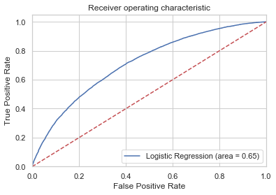

```python
from sklearn.metrics import roc_auc_score
from sklearn.metrics import roc_curve


logit_roc_auc = roc_auc_score(Y_test, y_pred_logit)
fpr_logit, tpr_logit, thresholds_logit = roc_curve(Y_test, LogReg1.predict_proba(X_test)[:,1])
plt.figure()
plt.plot(fpr_logit, tpr_logit, label='Logistic Regression (area = %0.2f)' % logit_roc_auc)
plt.plot([0, 1], [0, 1],'r--')
plt.xlim([0.0, 1.0])
plt.ylim([0.0, 1.05])
plt.xlabel('False Positive Rate')
plt.ylabel('True Positive Rate')
plt.title('Receiver operating characteristic')
plt.legend(loc="lower right")
plt.savefig('Log_ROC')
plt.show()
```

## 10.- Support Vector Machine (SVM)

El modelo que vamos a probar será un SVM. Este algoritmo de machine learning es usado para problemas de clasificación y regresión, ya que permite la distinción de los elementos de una muestra en categorías. Para la separación utiliza la figura del hiperplano, así uno de sus objetivos es que este hiperplano maximice la distancia a los márgenes.

```python
from sklearn import svm
from sklearn.svm import LinearSVC

modelo_svm = LinearSVC(penalty='l2', loss='squared_hinge',
                dual=False,
                tol=0.001, C=1,
                multi_class='ovr',
                random_state=123, max_iter=10000)

modelo_svm.fit(X_train,Y_train)
```

```
LinearSVC(C=1, class_weight=None, dual=False, fit_intercept=True,
          intercept_scaling=1, loss='squared_hinge', max_iter=10000,
          multi_class='ovr', penalty='l2', random_state=123, tol=0.001,
          verbose=0)
```

```python
modelo_svm.score(X_train, Y_train)
SVM_predicted = modelo_svm.predict(X_test)
```

### Metricas de Acierto :

```python
precision_svm, recall_svm, thresholds_svm =  metrics.roc_curve(Y_test, SVM_predicted)
metrics.auc(precision_svm, recall_svm)
```

```
0.6545394957284858
```

## 11.- Random forest classifier

```python
import numpy as np
import pandas as pd
import matplotlib
from matplotlib import pyplot as plt # plots
import seaborn as sns # plots
from scipy import stats as sts # normality test JB
from sklearn import model_selection
from sklearn import linear_model
from sklearn.linear_model import Ridge, RidgeCV # Ridge
from sklearn.linear_model import Lasso, LassoCV # Lasso
from sklearn.metrics import r2_score # R^2
from sklearn.model_selection import train_test_split # split data
from sklearn.metrics import mean_squared_error # MSE
from sklearn.preprocessing import StandardScaler # estandarization
from sklearn import preprocessing # estandarization
from sklearn.ensemble import IsolationForest # outliers
from math import sqrt # sqrt
import itertools # aplanar arrays
import math
import random
from sklearn.utils import resample
from sklearn.linear_model import LogisticRegression
from sklearn.preprocessing import RobustScaler
import matplotlib.pyplot as plt
from sklearn.ensemble import RandomForestClassifier
from sklearn.linear_model import SGDClassifier
from sklearn.pipeline import Pipeline
from sklearn.preprocessing import Imputer, StandardScaler
```

Entrenamos un modelo de Random Forest. Tenemos en cuenta que la estandarización de datos no es necesaria para un bosque aleatorio.

```python
pipeline_rfc = Pipeline([
    ('imputer', Imputer(copy=False)),
    ('model', RandomForestClassifier(n_jobs=-1, random_state=1))
])
```

El Random Forest tarda mucho en entrenarse, por lo que no probamos diferentes opciones de hiperparámetros. Seguiremos usando `GridSearchCV` en aras de la coherencia.

```python
param_grid_rfc = {
    'model__n_estimators': [50] # The number of randomized trees to build
}
```

El AUROC siempre mejorará (con ganancias decrecientes) a medida que aumente el número de estimadores, pero no necesariamente vale la pena el tiempo de entrenamiento adicional y la complejidad del modelo.

```python
grid_rfc = GridSearchCV(estimator=pipeline_rfc, param_grid=param_grid_rfc, scoring='roc_auc', n_jobs=-1, pre_dispatch='2*n_jobs', cv=10, verbose=1, return_train_score=False)
```

```python
grid_rfc.fit(X_train, Y_train)
```

```
Fitting 10 folds for each of 1 candidates, totalling 10 fits
```

```
GridSearchCV(cv=10, error_score='raise-deprecating',
             estimator=Pipeline(memory=None,
                                steps=[('imputer',
                                        Imputer(axis=0, copy=False,
                                                missing_values='NaN',
                                                strategy='mean', verbose=0)),
                                       ('model',
                                        RandomForestClassifier(bootstrap=True,
                                                               class_weight=None,
                                                               criterion='gini',
                                                               max_depth=None,
                                                               max_features='auto',
                                                               max_leaf_nodes=None,
                                                               min_impurity_decrease=0.0,
                                                               min_impurity_split=None,
                                                               min_samples_leaf=1,
                                                               min_samples_split=2,
                                                               min_weight_fraction_leaf=0.0,
                                                               n_estimators='warn',
                                                               n_jobs=-1,
                                                               oob_score=False,
                                                               random_state=1,
                                                               verbose=0,
                                                               warm_start=False))],
                                verbose=False),
             iid='warn', n_jobs=-1, param_grid={'model__n_estimators': [50]},
             pre_dispatch='2*n_jobs', refit=True, return_train_score=False,
             scoring='roc_auc', verbose=1)
```

Puntuación media de AUROC con validación cruzada del bosque aleatorio:

```python
grid_rfc.best_score_
```

```
0.6999217057400454
```

```python
RF_predicted = grid_rfc.predict(X_test)
y_pred_RF = RF_predicted
from sklearn.metrics import confusion_matrix
confusion_matrix_RF = confusion_matrix(Y_test, y_pred_RF)
print(confusion_matrix_RF)
```

```
[[12640  6646]
 [ 6938 12317]]
```

# 12.- XGBoost

```python
#!pip install xgboost
```

```python
# Determine the path to use XGBOOST
import os
mingw_path = 'C:\Program Files\mingw-w64\x86_64-8.1.0-posix-seh-rt_v6-rev0\mingw64\bin'
os.environ['PATH'] = mingw_path + ';' + os.environ['PATH']
```

```python
from xgboost import XGBClassifier

XGBC= XGBClassifier(random_state=123)

%time XGBC.fit(X_train, Y_train)
y_pred_xgb = XGBC.predict(np.array(X_test))
```

```
Wall time: 33.7 s
```

```python
#Obtain AUC metric
from sklearn import metrics

precision_xgb, recall_xgb, thresholds_xgb =  metrics.roc_curve(Y_test, y_pred_xgb)
metrics.auc(precision_xgb, recall_xgb)
```

```
0.6570450071445704
```

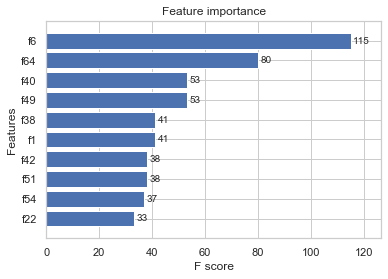

```python
# Plot variables importance
from xgboost import plot_importance
plot_importance(XGBC, height= 0.8, max_num_features= 10)
```

```python
print('Las tres varaibles con mayor importancia en el modelo de XGBoost fueron:', '\n',
      A_train.columns[0], '\n', A_train.columns[2], '\n', A_train.columns[22])
```

[output not shown]

```python
from sklearn.metrics import confusion_matrix
confusion_matrix_xgb = confusion_matrix(Y_test, y_pred_xgb)
print(confusion_matrix_xgb)
```

```
[[12565  6721]
 [ 6497 12758]]
```

# 13.- Conclusiones

Este modelo, aunque lejos de ser perfecto, puede proporcionar una predicción algo informada de la probabilidad de que un préstamo se pague, utilizando solo los datos disponibles para los posibles inversores antes de que el préstamo esté totalmente financiado.